# INFOSCI 301 Week 4 Network Idiom Studio

**Real data:** Zachary's Karate Club network and a reproducible OpenAlex scholarly-metadata snapshot.  
**Question:** Which network idiom and algorithm make the user's task possible without turning structure into decoration?  
**Final-project addition:** one network design decision, one output, one evidence boundary, and one next test.

This notebook follows **Domain -> Data and Task -> Idiom -> Algorithm (validate each level)**. Run all cells. The bundled snapshot works offline; the optional API-refresh cell is clearly marked.

## Definition of done

1. State a user and task: find, compare, trace, identify clusters, or explain change.
2. Build a node-edge table from a real dataset.
3. Compare at least two layouts and two structural measures.
4. Produce one static and one interactive network view.
5. State what the view supports, what it does not establish, and what you will add to the group MVP.

```python
# Colab-safe setup: install only packages that are missing.
import importlib.util, subprocess, sys

requirements = {
    "networkx": "networkx>=3.3", "pandas": "pandas>=2.2", "numpy": "numpy>=1.26",
    "matplotlib": "matplotlib>=3.8", "plotly": "plotly>=5.22", "sklearn": "scikit-learn>=1.4",
    "community": "python-louvain>=0.16", "igraph": "igraph>=0.11", "leidenalg": "leidenalg>=0.10",
    "pyvis": "pyvis>=0.3.2", "graphviz": "graphviz>=0.20", "pycirclize": "pycirclize>=1.6",
    "holoviews": "holoviews>=1.19", "hvplot": "hvplot>=0.11", "datashader": "datashader>=0.16",
    "sknetwork": "scikit-network>=0.33", "bokeh": "bokeh>=3.5"
}
missing = [pkg for module, pkg in requirements.items() if importlib.util.find_spec(module) is None]
if missing:
    subprocess.check_call([sys.executable, "-m", "pip", "install", "-q", *missing])
print(f"Environment ready. Installed {len(missing)} missing package(s).")
```

```
Environment ready. Installed 0 missing package(s).
```

```python
from pathlib import Path
from collections import Counter
import base64, gzip, io, json, math, textwrap, warnings
import numpy as np
import pandas as pd
import matplotlib.pyplot as plt
import networkx as nx
import plotly.graph_objects as go
from sklearn.feature_extraction.text import TfidfVectorizer
from sklearn.metrics.pairwise import cosine_similarity
from IPython.display import HTML, display

warnings.filterwarnings("ignore")
plt.rcParams.update({"figure.dpi": 120, "font.size": 10, "axes.titlesize": 12})
OUTPUT = Path("outputs")
OUTPUT.mkdir(exist_ok=True)
NAVY, TEAL, PURPLE, GOLD, CORAL = "#173F4A", "#21747A", "#6A5983", "#C59A43", "#C76D5A"
```

## Part A One network, four layouts

Zachary's Karate Club is an observed social network of 34 club members and 78 ties. The split attribute lets us compare visual patterns with a known social outcome.

```python
G = nx.karate_club_graph()
print({"nodes": G.number_of_nodes(), "edges": G.number_of_edges(), "density": round(nx.density(G), 3)})
pd.DataFrame(G.edges(), columns=["source", "target"]).head()
```

```
{'nodes': 34, 'edges': 78, 'density': 0.139}
```

|  | source | target |
| --- | --- | --- |
| 0 | 0 | 1 |
| 1 | 0 | 2 |
| 2 | 0 | 3 |
| 3 | 0 | 4 |
| 4 | 0 | 5 |

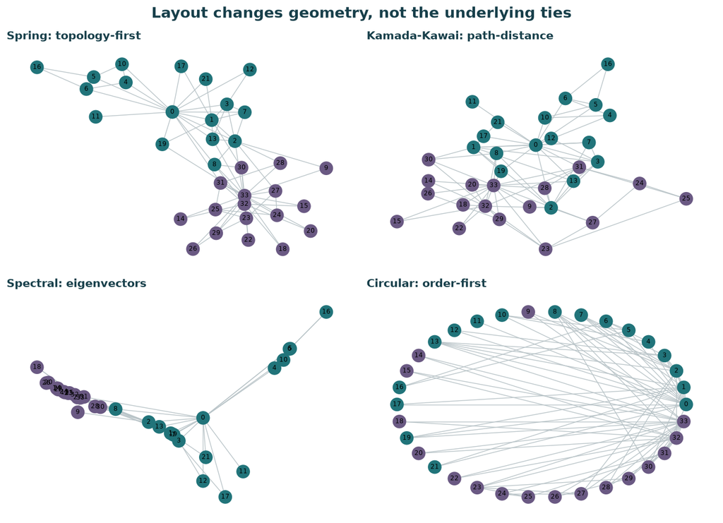

```python
layouts = {
    "Spring: topology-first": nx.spring_layout(G, seed=301),
    "Kamada-Kawai: path-distance": nx.kamada_kawai_layout(G),
    "Spectral: eigenvectors": nx.spectral_layout(G),
    "Circular: order-first": nx.circular_layout(G),
}
club_color = [TEAL if G.nodes[n]["club"] == "Mr. Hi" else PURPLE for n in G]
fig, axes = plt.subplots(2, 2, figsize=(11, 8))
for ax, (label, pos) in zip(axes.flat, layouts.items()):
    nx.draw_networkx(G, pos, ax=ax, node_color=club_color, node_size=190,
                     edge_color="#B9C4C8", width=.8, font_size=7)
    ax.set_title(label, loc="left", fontweight="bold", color=NAVY)
    ax.axis("off")
fig.suptitle("Layout changes geometry, not the underlying ties", fontsize=16, fontweight="bold", color=NAVY)
fig.tight_layout()
fig.savefig(OUTPUT / "network_layout_comparison.png", bbox_inches="tight")
plt.show()
```

**Interpretation check.** A layout is an algorithmic hypothesis about useful geometry. Spring and Kamada-Kawai layouts can reveal topology, but distance on the page is not geographic distance or causal influence. Circular layouts preserve a chosen order and make crossings easier to compare, but do not reveal clusters automatically.

## Part B Measures and communities

Use measures only when they answer a stated task. Degree supports local-connectivity questions, betweenness supports possible brokerage, PageRank supports recursive prominence, and k-core supports cohesive-subgraph questions.

```python
metrics = pd.DataFrame({
    "node": list(G.nodes()),
    "club": [G.nodes[n]["club"] for n in G],
    "degree": pd.Series(dict(G.degree())),
    "degree_centrality": pd.Series(nx.degree_centrality(G)),
    "betweenness": pd.Series(nx.betweenness_centrality(G)),
    "pagerank": pd.Series(nx.pagerank(G)),
    "clustering": pd.Series(nx.clustering(G)),
    "k_core": pd.Series(nx.core_number(G)),
}).sort_values("betweenness", ascending=False)
metrics.head(10).style.format({"degree_centrality":"{:.3f}", "betweenness":"{:.3f}", "pagerank":"{:.3f}", "clustering":"{:.3f}"})
```

|  | node | club | degree | degree_centrality | betweenness | pagerank | clustering | k_core |
| --- | --- | --- | --- | --- | --- | --- | --- | --- |
| 0 | 0 | Mr. Hi | 16 | 0.485 | 0.438 | 0.089 | 0.150 | 4 |
| 33 | 33 | Officer | 17 | 0.515 | 0.304 | 0.097 | 0.110 | 4 |
| 32 | 32 | Officer | 12 | 0.364 | 0.145 | 0.076 | 0.197 | 4 |
| 2 | 2 | Mr. Hi | 10 | 0.303 | 0.144 | 0.063 | 0.244 | 4 |
| 31 | 31 | Officer | 6 | 0.182 | 0.138 | 0.042 | 0.200 | 3 |
| 8 | 8 | Mr. Hi | 5 | 0.152 | 0.056 | 0.033 | 0.500 | 4 |
| 1 | 1 | Mr. Hi | 9 | 0.273 | 0.054 | 0.057 | 0.333 | 4 |
| 13 | 13 | Mr. Hi | 5 | 0.152 | 0.046 | 0.033 | 0.600 | 4 |
| 19 | 19 | Mr. Hi | 3 | 0.091 | 0.032 | 0.013 | 0.333 | 3 |
| 5 | 5 | Mr. Hi | 4 | 0.121 | 0.030 | 0.034 | 0.500 | 3 |

|  | algorithm | communities | modularity |
| --- | --- | --- | --- |
| 0 | Louvain | 4 | 0.428 |
| 1 | Label propagation | 3 | 0.413 |
| 2 | Leiden | 4 | 0.445 |

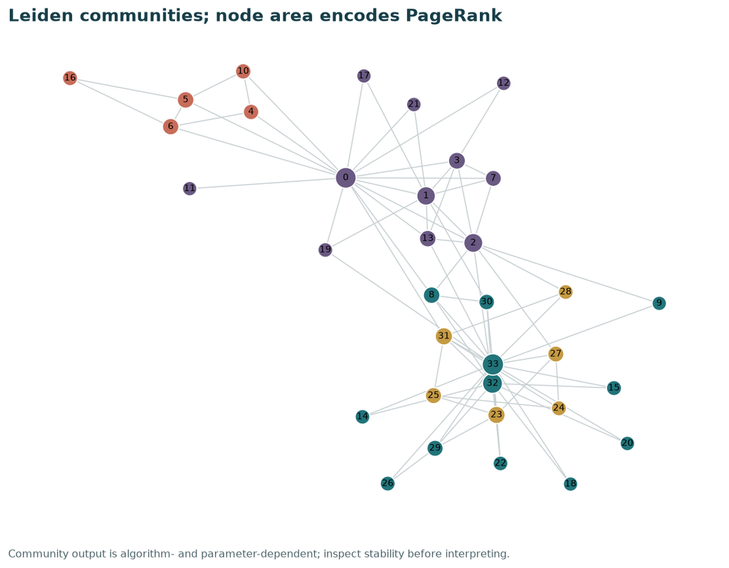

```python
louvain = list(nx.community.louvain_communities(G, seed=301))
label_prop = list(nx.community.asyn_lpa_communities(G, seed=301))

import igraph as ig
import leidenalg
edge_list = list(G.edges())
ig_graph = ig.Graph(n=G.number_of_nodes(), edges=edge_list, directed=False)
leiden_partition = leidenalg.find_partition(ig_graph, leidenalg.ModularityVertexPartition, seed=301)
leiden = [set(c) for c in leiden_partition]

summary = pd.DataFrame([
    ["Louvain", len(louvain), nx.community.modularity(G, louvain)],
    ["Label propagation", len(label_prop), nx.community.modularity(G, label_prop)],
    ["Leiden", len(leiden), nx.community.modularity(G, leiden)],
], columns=["algorithm", "communities", "modularity"])
display(summary.style.format({"modularity":"{:.3f}"}))

membership = {node: i for i, group in enumerate(leiden) for node in group}
pos = nx.spring_layout(G, seed=301)
palette = [TEAL, PURPLE, GOLD, CORAL, NAVY]
fig, ax = plt.subplots(figsize=(9, 7))
nx.draw_networkx_edges(G, pos, ax=ax, edge_color="#C8D0D3", width=.9)
nx.draw_networkx_nodes(G, pos, ax=ax,
                       node_color=[palette[membership[n] % len(palette)] for n in G],
                       node_size=[140 + 2200 * metrics.set_index("node").loc[n, "pagerank"] for n in G],
                       edgecolors="white", linewidths=1)
nx.draw_networkx_labels(G, pos, ax=ax, font_size=8)
ax.set_title("Leiden communities; node area encodes PageRank", loc="left", fontsize=15, fontweight="bold", color=NAVY)
ax.text(0, -0.06, "Community output is algorithm- and parameter-dependent; inspect stability before interpreting.",
        transform=ax.transAxes, fontsize=9, color="#4F646B")
ax.axis("off")
fig.tight_layout()
fig.savefig(OUTPUT / "network_community_centrality.png", bbox_inches="tight")
plt.show()
```

## Part C Interactive, hierarchical, and circular idioms

```python
# Plotly: inspect node details without labeling every mark.
edge_x, edge_y = [], []
for u, v in G.edges():
    edge_x += [pos[u][0], pos[v][0], None]
    edge_y += [pos[u][1], pos[v][1], None]
edge_trace = go.Scatter(x=edge_x, y=edge_y, mode="lines", hoverinfo="none", line=dict(width=.7, color="#BBC6C9"))
ordered = list(G.nodes())
node_trace = go.Scatter(
    x=[pos[n][0] for n in ordered], y=[pos[n][1] for n in ordered], mode="markers",
    text=[f"Node {n}<br>Club: {G.nodes[n]['club']}<br>PageRank: {nx.pagerank(G)[n]:.3f}" for n in ordered],
    hoverinfo="text", marker=dict(size=[10 + 90 * nx.pagerank(G)[n] for n in ordered],
                                   color=[membership[n] for n in ordered], colorscale="Viridis", line=dict(width=1, color="white")))
fig = go.Figure([edge_trace, node_trace])
fig.update_layout(title="Interactive inspection: Karate Club", showlegend=False, margin=dict(l=10,r=10,t=45,b=10),
                  xaxis=dict(visible=False), yaxis=dict(visible=False), height=600)
fig.write_html(OUTPUT / "karate_plotly.html", include_plotlyjs="cdn")
fig.show()
```

[interactive chart not shown]

```python
# PyVis: physics, drag, hover, and neighborhood inspection.
from pyvis.network import Network
pyvis_net = Network(height="560px", width="100%", bgcolor="#FFFFFF", font_color=NAVY, notebook=True, cdn_resources="in_line")
for n in G:
    pyvis_net.add_node(n, label=str(n), title=f"Club: {G.nodes[n]['club']}", value=G.degree(n), group=membership[n])
for u, v in G.edges():
    pyvis_net.add_edge(u, v)
pyvis_net.toggle_physics(True)
pyvis_path = OUTPUT / "karate_pyvis.html"
pyvis_net.write_html(str(pyvis_path), open_browser=False)
display(HTML(pyvis_path.read_text(encoding="utf-8")))
```

```python
# Graphviz: use a directed, hierarchical idiom for an explanation path.
from graphviz import Digraph
dot = Digraph("network_reasoning", format="png")
dot.attr(rankdir="LR", bgcolor="transparent")
for node, color in [("task", TEAL), ("model", PURPLE), ("layout", GOLD), ("evidence", CORAL), ("claim", NAVY)]:
    dot.node(node, node.title(), shape="box", style="rounded,filled", fillcolor=color, fontcolor="white")
dot.edges([("task", "model"), ("model", "layout"), ("layout", "evidence"), ("evidence", "claim")])
try:
    graphviz_path = dot.render(filename="network_reasoning_graphviz", directory=str(OUTPUT), cleanup=True)
    display(HTML(f"<p><b>Graphviz output:</b> {graphviz_path}</p>"))
except Exception as exc:
    source_path = OUTPUT / "network_reasoning_graphviz.gv"
    source_path.write_text(dot.source, encoding="utf-8")
    display(HTML(f"<p><b>Graphviz source saved:</b> {source_path}. The local renderer was unavailable ({type(exc).__name__}); Colab normally installs the Graphviz executable.</p>"))
```

**Graphviz source saved:** outputs/network_reasoning_graphviz.gv. The local renderer was unavailable (ExecutableNotFound); Colab normally installs the Graphviz executable.

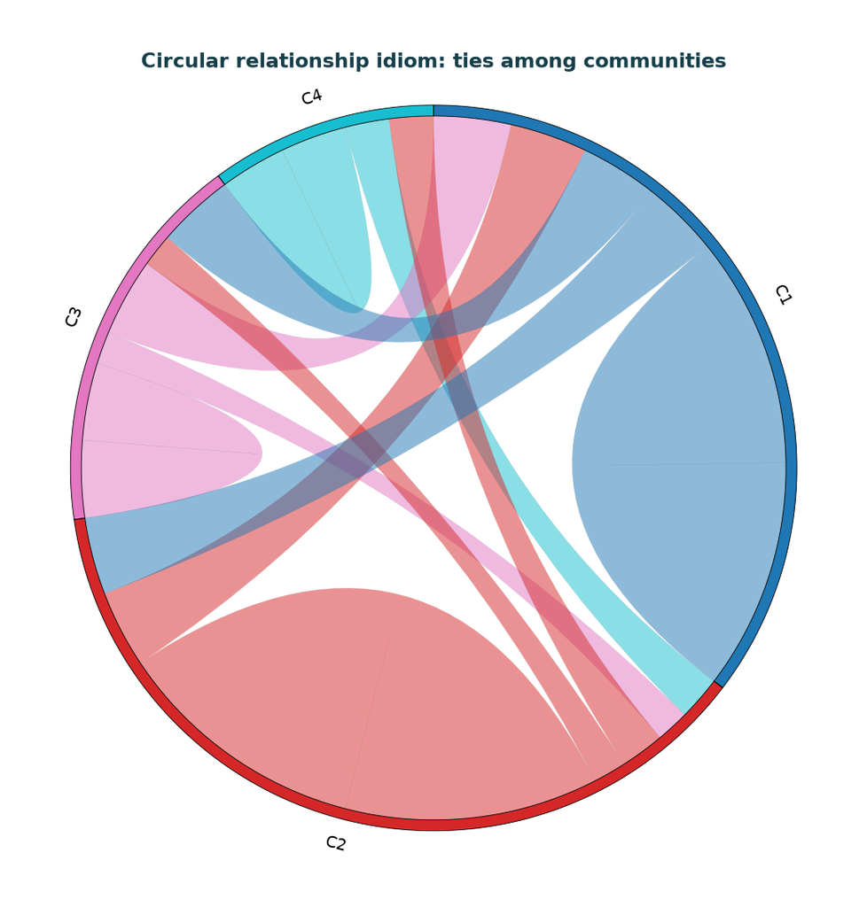

```python
# pyCirclize: chord-like view of ties between detected communities.
from pycirclize import Circos
comm_ids = sorted(set(membership.values()))
matrix = pd.DataFrame(0, index=[f"C{i+1}" for i in comm_ids], columns=[f"C{i+1}" for i in comm_ids])
for u, v in G.edges():
    a, b = f"C{membership[u]+1}", f"C{membership[v]+1}"
    matrix.loc[a, b] += 1
    if a != b:
        matrix.loc[b, a] += 1
circos = Circos.chord_diagram(matrix, cmap="tab10", label_kws=dict(size=11))
fig = circos.plotfig()
fig.suptitle("Circular relationship idiom: ties among communities", fontsize=14, fontweight="bold", color=NAVY)
fig.savefig(OUTPUT / "network_pycirclize.png", bbox_inches="tight")
plt.show()
```

## Part D Scale-up view with HoloViews and Datashader

```python
import holoviews as hv
from holoviews.operation.datashader import datashade, bundle_graph
hv.extension("bokeh")
hv_graph = hv.Graph.from_networkx(G, nx.spring_layout, seed=301).opts(
    node_size=8, node_color="index", cmap="Viridis", edge_color="#8EA1A7", width=720, height=480,
    tools=["hover"], title="HoloViews graph; Datashader route for larger networks"
)
display(hv_graph)
```

```
:Graph   [start,end]   (weight)
```

## Part E Knowledge graph and NLP with OpenAlex

The snapshot is real scholarly metadata retrieved from OpenAlex. We build a heterogeneous graph of papers, authors, and topics, then add paper-to-paper similarity edges from TF-IDF. Similarity is a text-model output, not proof of intellectual influence.

```python
OPENALEX_SNAPSHOT_B64 = "H4sIABwlqGoC/729a3PbWLIt+FcQjpjbcgRFk6Koh/vDCVmyXS7bZbflKp/u…="
works = json.loads(gzip.decompress(base64.b64decode(OPENALEX_SNAPSHOT_B64)).decode("utf-8"))
works_df = pd.DataFrame(works)
print(f"Loaded {len(works_df)} OpenAlex works from the bundled snapshot.")
display(works_df[["title", "year", "cited_by_count", "source"]].head(10))
```

```
Loaded 40 OpenAlex works from the bundled snapshot.
```

|  | title | year | cited_by_count | source |
| --- | --- | --- | --- | --- |
| 0 | Visual Analytics: Definition, Process, and Cha... | 2008 | 1062 | Lecture notes in computer science |
| 1 | Beyond the hype: Big data concepts, methods, a... | 2014 | 4200 | International Journal of Information Management |
| 2 | Critical analysis of Big Data challenges and a... | 2016 | 2054 | Journal of Business Research |
| 3 | Space, time and visual analytics | 2010 | 433 | International Journal of Geographical Informat... |
| 4 | Street view imagery in urban analytics and GIS... | 2021 | 892 | Landscape and Urban Planning |
| 5 | Challenges in Visual Data Analysis | 2006 | 397 |  |
| 6 | Visualization and analytics tools for infectio... | 2014 | 261 | Journal of Biomedical Informatics |
| 7 | Social media analytics: a survey of techniques... | 2014 | 706 | AI & Society |
| 8 | Visualizing and Interacting with Geospatial Ne... | 2021 | 62 | Computer Graphics Forum |
| 9 | Geospatial Data Management Research: Progress ... | 2020 | 194 | ISPRS International Journal of Geo-Information |

```python
# Build paper-author-topic knowledge graph from the most cited 22 works.
selected = works_df.sort_values("cited_by_count", ascending=False).head(22).copy()
KG = nx.Graph()
for _, work in selected.iterrows():
    pid = work["id"]
    KG.add_node(pid, label=work["title"], kind="paper", year=work["year"], citations=work["cited_by_count"])
    for author in work["authors"][:5]:
        aid = f"author::{author}"
        KG.add_node(aid, label=author, kind="author")
        KG.add_edge(pid, aid, relation="authored_by")
    for topic in work["topics"][:3]:
        tid = f"topic::{topic}"
        KG.add_node(tid, label=topic, kind="topic")
        KG.add_edge(pid, tid, relation="has_topic")

corpus = (selected["title"] + " " + selected["abstract"].fillna("")).tolist()
vectors = TfidfVectorizer(stop_words="english", max_features=1200, ngram_range=(1, 2)).fit_transform(corpus)
similarity = cosine_similarity(vectors)
ids = selected["id"].tolist()
candidate_edges = []
for i in range(len(ids)):
    for j in range(i + 1, len(ids)):
        candidate_edges.append((similarity[i, j], ids[i], ids[j]))
for score, u, v in sorted(candidate_edges, reverse=True)[:28]:
    if score > 0.08:
        KG.add_edge(u, v, relation="text_similarity", weight=float(score))
print({"nodes": KG.number_of_nodes(), "edges": KG.number_of_edges(), "node_types": Counter(nx.get_node_attributes(KG, "kind").values())})
```

```
{'nodes': 134, 'edges': 173, 'node_types': Counter({'author': 75, 'topic': 37, 'paper': 22})}
```

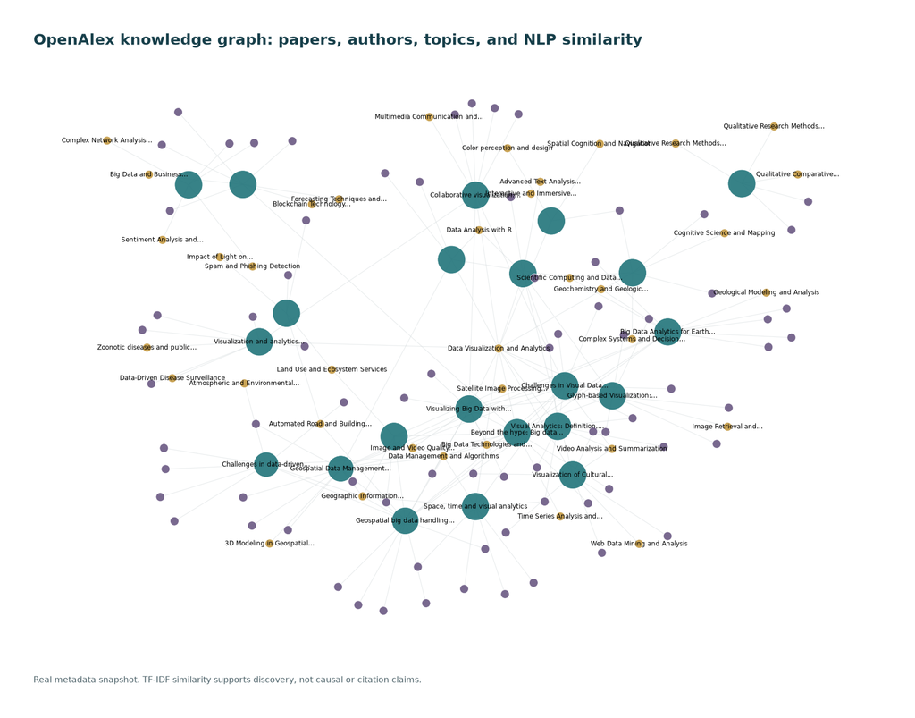

```python
# Readable overview: label topics, top authors, and top papers only.
pos_kg = nx.spring_layout(KG, seed=301, k=0.65, iterations=150)
kinds = nx.get_node_attributes(KG, "kind")
colors = {"paper": TEAL, "author": PURPLE, "topic": GOLD}
sizes = {n: (210 + 3 * KG.nodes[n].get("citations", 0)) if kinds[n] == "paper" else 85 for n in KG}
fig, ax = plt.subplots(figsize=(13, 10))
nx.draw_networkx_edges(KG, pos_kg, ax=ax, edge_color="#D0D7D9", alpha=.45, width=.7)
nx.draw_networkx_nodes(KG, pos_kg, ax=ax, node_color=[colors[kinds[n]] for n in KG],
                       node_size=[min(sizes[n], 900) for n in KG], alpha=.9, linewidths=.5, edgecolors="white")
ranked = sorted(KG.degree(), key=lambda x: x[1], reverse=True)[:14]
label_nodes = {n for n, _ in ranked} | {n for n in KG if kinds[n] == "topic"}
labels = {n: textwrap.shorten(KG.nodes[n]["label"], width=32, placeholder="...") for n in label_nodes}
nx.draw_networkx_labels(KG, pos_kg, labels, font_size=7, ax=ax)
ax.set_title("OpenAlex knowledge graph: papers, authors, topics, and NLP similarity", loc="left", fontsize=16, fontweight="bold", color=NAVY)
ax.text(0, -0.03, "Real metadata snapshot. TF-IDF similarity supports discovery, not causal or citation claims.", transform=ax.transAxes, fontsize=9, color="#4F646B")
ax.axis("off")
fig.tight_layout()
fig.savefig(OUTPUT / "openalex_knowledge_graph.png", bbox_inches="tight")
plt.show()
```

```python
# scikit-network: sparse-graph PageRank route for larger graphs.
from scipy import sparse
from sknetwork.ranking import PageRank
node_order = list(KG.nodes())
sparse_adj = nx.to_scipy_sparse_array(KG, nodelist=node_order, dtype=float, format="csr")
scores = PageRank().fit_predict(sparse.csr_matrix(sparse_adj))
skn_rank = pd.DataFrame({"node": node_order, "label": [KG.nodes[n]["label"] for n in node_order], "kind": [kinds[n] for n in node_order], "pagerank": scores})
display(skn_rank.sort_values("pagerank", ascending=False).head(12))
```

|  | node | label | kind | pagerank |
| --- | --- | --- | --- | --- |
| 10 | topic::Data Visualization and Analytics | Data Visualization and Analytics | topic | 0.036912 |
| 106 | W2018681530 | Big Data Analytics for Earth Sciences: the Ear... | paper | 0.027262 |
| 120 | W3005359275 | Geospatial Data Management Research: Progress ... | paper | 0.026034 |
| 114 | W2344199778 | Geospatial big data handling theory and method... | paper | 0.025786 |
| 91 | W2151103962 | Visualization and analytics tools for infectio... | paper | 0.024610 |
| 67 | W1961379460 | Visualizing Big Data with augmented and virtua... | paper | 0.024416 |
| 73 | W2135577168 | Collaborative visualization: Definition, chall... | paper | 0.024349 |
| 12 | W2487200295 | Critical analysis of Big Data challenges and a... | paper | 0.024330 |
| 127 | W4405571084 | Challenges in data-driven geospatial modeling ... | paper | 0.023545 |
| 84 | W2152762220 | Glyph-based Visualization: Foundations, Design... | paper | 0.023103 |
| 99 | W2801516600 | Visualization of Cultural Heritage Collection ... | paper | 0.022739 |
| 44 | W2085864217 | Space, time and visual analytics | paper | 0.020369 |

### Optional live refresh

OpenAlex access rules can change. Keep the bundled snapshot for reproducibility. If you refresh, record the query URL, date, result count, and any API key requirement in your project provenance file.

```python
# OPTIONAL: uncomment to refresh from OpenAlex.
# import requests
# url = "https://api.openalex.org/works?search=network%20visualization%20knowledge%20graph&per-page=40"
# live = requests.get(url, timeout=60).json()
# print(len(live.get("results", [])))
print("Optional refresh left off so the executed notebook remains reproducible.")
```

```
Optional refresh left off so the executed notebook remains reproducible.
```

## Final-project transfer task

Add one paragraph and one figure to your team claim:

- **Network question and task:** Who or what are the nodes and edges? What should the intended user find, compare, trace, or explain?
- **Idiom:** node-link, matrix, hierarchy, Sankey/alluvial, arc, chord, or small multiples. Why is it appropriate?
- **Algorithm:** layout, centrality, community, path, similarity, or temporal comparison. What parameter or instability matters?
- **Evidence boundary:** What does the graph omit? What relationship is inferred rather than observed?
- **MVP addition:** What will be demonstrable in Week 5 and tested in Week 6?

**Required submission evidence:** saved output, caption with claim and boundary, code cell or function, source and license note, accessibility fallback, and one next test.

## Selected references and projects

- NetworkX documentation: https://networkx.org/documentation/stable/reference/algorithms/
- OpenAlex API reference: https://help.openalex.org/api/
- Beck, Burch, Diehl, and Weiskopf. *A Taxonomy and Survey of Dynamic Graph Visualization*. Computer Graphics Forum 36(1), 2017. https://doi.org/10.1111/cgf.12791
- Nobre et al. *The State of the Art in Visualizing Multivariate Networks*. Computer Graphics Forum 38(3), 2019. https://doi.org/10.1111/cgf.13728
- Ilievski et al. *KGTK: A Toolkit for Large Knowledge Graph Manipulation and Analysis*. ISWC 2020. https://doi.org/10.1007/978-3-030-62466-8_16
- PyVis: https://pyvis.readthedocs.io/ | Graphviz: https://graphviz.org/ | HoloViews: https://holoviews.org/ | Datashader: https://datashader.org/

## Atlas Studio enhancement · four levels, four validation tests

**Domain → Data/Task → Idiom → Algorithm. Validation belongs at every level; it is not a fifth level.**

Keep the original package experiments below/above as optional depth. The new cells connect them to a real communication or community question. The self-contained snapshots are embedded, so downloading just this notebook is enough for the new data examples. No live API call is required.

| Level | Decision | Validation evidence | Project addition |
| --- | --- | --- | --- |
| Domain | Audience/community, need and task | Observation/interview; whose need is not established? | Refined shared research question |
| Data/Task | Unit, relationship, time, coverage | Source record checks; domain-informed abstraction review | Data dictionary and provenance |
| Idiom | Basic baseline + advanced view | Observed task comparison, errors, accessibility | Justified linked-view design |
| Algorithm | Transformation, parameters and computation | Tests, reproducibility, sensitivity | Working MVP and evidence record |

**Week 4 → Week 5 → Week 6 → Week 7:** individual evidence and Reflection 1 → proposal plus MVP → demonstration/user study/feedback/response (15%) → future-roadmap roundtable (5%) and Reflection 2. These 15% and 5% are the split of the existing 20% component, not extra grading weight.

### Scientific communication of emerging technology

**Domain:** A museum educator wants to explain geospatial AI. What misunderstanding should the communication prevent? Ask an audience member; do not treat this hypothetical persona as validated need.

**Data/Task:** The new snapshot contains 60 OpenAlex results for “geospatial artificial intelligence,” filtered from 2019. Every link below means **provider-assigned topic**, not citation, causal claim or a verified NLP relation. Topic score is not our accuracy estimate.

Source: https://api.openalex.org/works?search=geospatial%20artificial%20intelligence&filter=from_publication_date:2019-01-01&per-page=60. Retrieved 2026-09-14. Metadata CC0; sample is not a systematic review.

```python
import base64, gzip, json
import networkx as nx, pandas as pd, matplotlib.pyplot as plt
from IPython.display import display
emerging_papers = json.loads(gzip.decompress(base64.b64decode('H4sIAHJwqGoC/8193XLbSJbmfT9FRt2MHSFKADIBJHyzQUuyJVuStaKqXO6O…=')))
print('Real OpenAlex records:', len(emerging_papers))
display(pd.DataFrame([{'id':p['id'], 'year':p['year'], 'title':p['title'], 'url':p['url']} for p in emerging_papers]).head(5))
```

```
Real OpenAlex records: 60
```

|  | id | year | title | url |
| --- | --- | --- | --- | --- |
| 0 | W4395055639 | 2024 | Foundation Models for Generalist Geospatial Ar... | https://doi.org/10.2139/ssrn.4804009 |
| 1 | W4389474133 | 2023 | Handbook of Geospatial Artificial Intelligence | https://doi.org/10.1201/9781003308423 |
| 2 | W4406643700 | 2025 | Towards the next generation of Geospatial Arti... | https://doi.org/10.1016/j.jag.2025.104368 |
| 3 | W4367313141 | 2023 | Advances in geocomputation and geospatial arti... | https://doi.org/10.1016/j.jag.2023.103300 |
| 4 | W4230451521 | 2021 | Geospatial Artificial Intelligence (GeoAI) | https://doi.org/10.1093/obo/9780199874002-0228 |

### Idiom comparison: count chart versus paper–topic graph

Keep the first 20 papers fixed. Compare the basic topic-count bar chart with a bipartite network. Ask a peer to identify a topic with several supporting papers, locate an original source, and explain what the graph cannot establish. Record errors and confidence; do not fill in fictional user-study results.

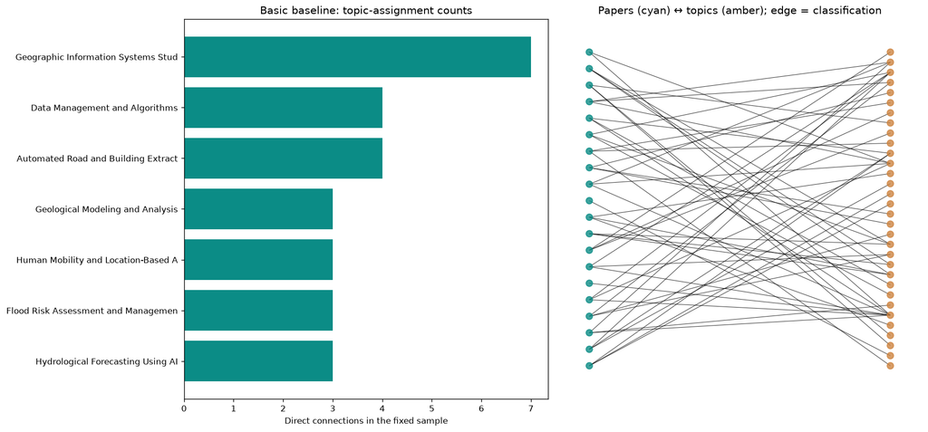

```python
sample = emerging_papers[:20]
comm_graph = nx.Graph()
for p in sample:
    comm_graph.add_node(p['id'], kind='paper', label=p['title'])
    for t in p['topics']:
        comm_graph.add_node(t['id'], kind='topic', label=t['label'])
        comm_graph.add_edge(p['id'], t['id'], relation='classified under', source=p['url'])
topics = sorted((n for n,d in comm_graph.nodes(data=True) if d['kind']=='topic'), key=lambda n:comm_graph.degree(n), reverse=True)
fig, axes = plt.subplots(1,2, figsize=(15,7))
top = topics[:7]
axes[0].barh([comm_graph.nodes[n]['label'][:35] for n in top][::-1], [comm_graph.degree(n) for n in top][::-1], color='#0b8c86')
axes[0].set_title('Basic baseline: topic-assignment counts')
axes[0].set_xlabel('Direct connections in the fixed sample')
pos = nx.bipartite_layout(comm_graph, [p['id'] for p in sample])
nx.draw(comm_graph, pos, ax=axes[1], node_size=55, width=.6, alpha=.8, node_color=['#0b8c86' if d['kind']=='paper' else '#ce8440' for _,d in comm_graph.nodes(data=True)])
axes[1].set_title('Papers (cyan) ↔ topics (amber); edge = classification')
plt.tight_layout(); plt.show()
```

```python
# Algorithm-level tests, not evidence of communication effectiveness.
rank = nx.pagerank(comm_graph, alpha=.85)
assert abs(sum(rank.values())-1) < 1e-8
assert sum(dict(comm_graph.degree()).values()) == 2*comm_graph.number_of_edges()
assert all(comm_graph.nodes[a]['kind'] != comm_graph.nodes[b]['kind'] for a,b in comm_graph.edges())
first_paper = sample[0]['id']
two_hop = nx.single_source_shortest_path_length(comm_graph, first_paper, cutoff=2)
print('Nodes:', comm_graph.number_of_nodes(), 'Edges:', comm_graph.number_of_edges())
print('Two-hop reachable nodes:', len(two_hop), '| Algorithm checks passed.')
```

```
Nodes: 52 Edges: 55
Two-hop reachable nodes: 11 | Algorithm checks passed.
```

### Innovation output: a source-grounded communication brief

1. Name the audience, decision and misconception.
2. Link one selected paper; distinguish its demonstrated finding from a hoped-for application.
3. State why the basic chart and the network are both needed.
4. For an NLP knowledge graph, attach source spans, extraction method, inferred/verified status and a human-check sample to every relation. Entity co-occurrence is not factual entailment.
5. Record a peer's actual interpretation and the change it prompted. Bring this brief and the data dictionary into the Week 5 MVP.